# R Markdown Primer

Jenee Marshall

2025-11-17

## Introduction

R Markdown lets me write normal text while also running R code in the same document.  
When I knit it, everything updates automatically, which feels really useful for data science classes.

So far, R Markdown feels different from writing a regular report because the code and the explanation stay together.  
It makes it easier to see why I did something, not just the final answer.  
I like that the format keeps everything organized, especially because I’m building data skills and need my work to be reproducible for school and future projects.

## Math Example - LaTex

I can also add simple math using LaTeX.  
This helps when I need to show formulas or write out steps clearly.

Inline example: $\\alpha + \\beta = \\gamma$

Displayed equation:

$$y = mx + b$$

This is just a basic slope line equation, but it shows that R Markdown can handle math cleanly.

# R Code Chunk 1: Loading a Library and Dataset

Here is my first code chunk. I’m loading **ggplot2** and looking at the built-in `mtcars` dataset.

```r
library(ggplot2)
head(mtcars)
```

```
##                    mpg cyl disp  hp drat    wt  qsec vs am gear carb
## Mazda RX4         21.0   6  160 110 3.90 2.620 16.46  0  1    4    4
## Mazda RX4 Wag     21.0   6  160 110 3.90 2.875 17.02  0  1    4    4
## Datsun 710        22.8   4  108  93 3.85 2.320 18.61  1  1    4    1
## Hornet 4 Drive    21.4   6  258 110 3.08 3.215 19.44  1  0    3    1
## Hornet Sportabout 18.7   8  360 175 3.15 3.440 17.02  0  0    3    2
## Valiant           18.1   6  225 105 2.76 3.460 20.22  1  0    3    1
```

```r
summary(mtcars$mpg)
```

```
##    Min. 1st Qu.  Median    Mean 3rd Qu.    Max.
##   10.40   15.43   19.20   20.09   22.80   33.90
```

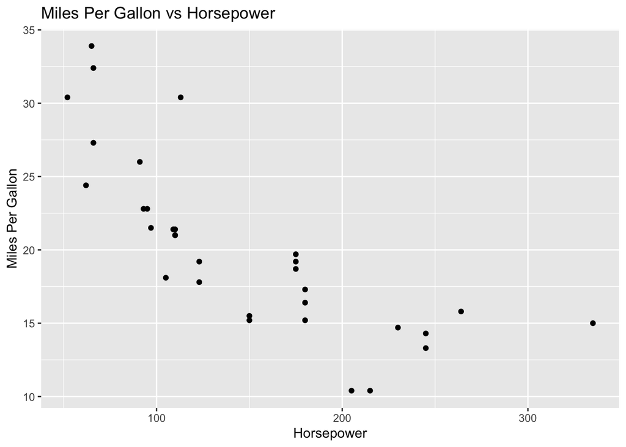

```r
ggplot(mtcars, aes(x = hp, y = mpg)) +
  geom_point() +
  labs(
    title = "Miles Per Gallon vs Horsepower",
    x = "Horsepower",
    y = "Miles Per Gallon"
  )
```

Using R Markdown makes my work feel more organized and easier to follow. Everything can be a bit more organized and structured. I like that the writing and the analysis stay connected, because it helps me understand what I’m doing instead of treating the code like a separate step. This is great for any future asignment or even any projects i would have to do.